# Senado Federal e Aprovações de Autoridades Indicadas Pelo Presidente da República

2024-08-22

## Objeto (tema central da apresentação)

O papel do Senado Federal no processo de aprovação de autoridades tem sido questionado quanto à sua atuação ativa ou deferente. Por muito tempo, a literatura considerou o papel do Senado Federal como deferente, dada a alta taxa de aprovação. Porém, uma literatura mais recente tem questionado se, de fato, esse papel não precisa ser visto considerando outras etapas do processo, considerando, por exemplo, que as preferências dos senadores são observadas para que nomes vencedores sejam indicados, ou considerando o tempo de tramitação nesse processo, e não somente a taxa de aprovação ou rejeição. Dessa forma, iremos observar o tempo de tramitação de aprovação de dois grupos de autoridades: diretores de agências nacionais e embaixadores. Tais grupos foram escolhidos considerando a importância para a governabilidade.

## Objetivo (questões de pesquisa que o trabalho irá responder)

A intenção final, e que não a alcançaremos aqui, é a de responder se o Senado Federal tem um papel ativo no processo de aprovação de autoridades.

Para chegar lá, posteriomente, a hipótese levantada nesse trabalho é a de que os cargos de diretores serão mais rapidamente aprovados dada a necessidade de governabilidade desse cargo em contraponto com o cargo de embaixadores.

## Contexto

Esse trabalho pretende fazer uma contribuição aos estudos a respeito do Senado Federal brasileiro, tendo em vista que é um assunto ainda pouco explorado. Parte da literatura enfatiza a fraqueza do Poder Legislativo comparado à força exercida pelo Poder Executivo (Figueiredo, 2001; Eaton, 2001; Mustapic, 2001; Loureiro, 2001; Siavelis, 2000), por vezes representando a aprovação pelo Senado Federal de nomeados pelo Poder Executivo como apenas uma formalidade, não cumprindo, assim, sua função de forma completa (Harris, 1968).

## Contexto

Em contraponto, há estudos que assumem o Legislativo como ator com grande força política, evidenciando o papel fundamental do Senado Federal (SF) para a estabilidade do governo e reconhecendo o papel na área econômica da Casa (Neiva, 2011); além disso, assumem que os interesses da casa alta se não considerados na própria casa, são considerados em outras etapas do processo decisório (Araújo, 2014). Segundo Llanos e Lemos (2005), a taxa de aprovação de autoridades pelo SF é mais alta que 90%, o que não significa que a Casa não cumpra sua função, mas que o tempo entre aprovação e nomeação indica que há negociação com o Senado Federal. Esse trabalho pretende verificar a efetividade de tais explicações e investigar a atuação do Senado nas nomeações pelo poder Executivo por um período de 10 anos – de 2010 até 2019, nos cargos de diretores e embaixadores.

## Metodologia

Os dados foram coletados manualmente do site oficial do Senado Federal, sendo coletados todos os cargos de diretores e embaixadores do ano de 2010 ao ano de 2019.

## Resultado do teste T

```r
# Realizar o teste t de duas amostras
resultado_teste <- t.test(tempo_de_tramitacao_dias_ate_a_aprovacao
                          ~ grupo, data = dados_combinados)
# Exibir os resultados do teste t
print(resultado_teste)
```

```
##
##  Welch Two Sample t-test
##
## data:  tempo_de_tramitacao_dias_ate_a_aprovacao by grupo
## t = -9.8157, df = 336.77, p-value < 2.2e-16
## alternative hypothesis: true difference in means between group Diretores and group Embaixadores is not equal to 0
## 95 percent confidence interval:
##  -40.25640 -26.81545
## sample estimates:
##    mean in group Diretores mean in group Embaixadores
##                   37.16556                   70.70149
```

## Visualizando a média do tempo de tramitação dos cargos selecionados

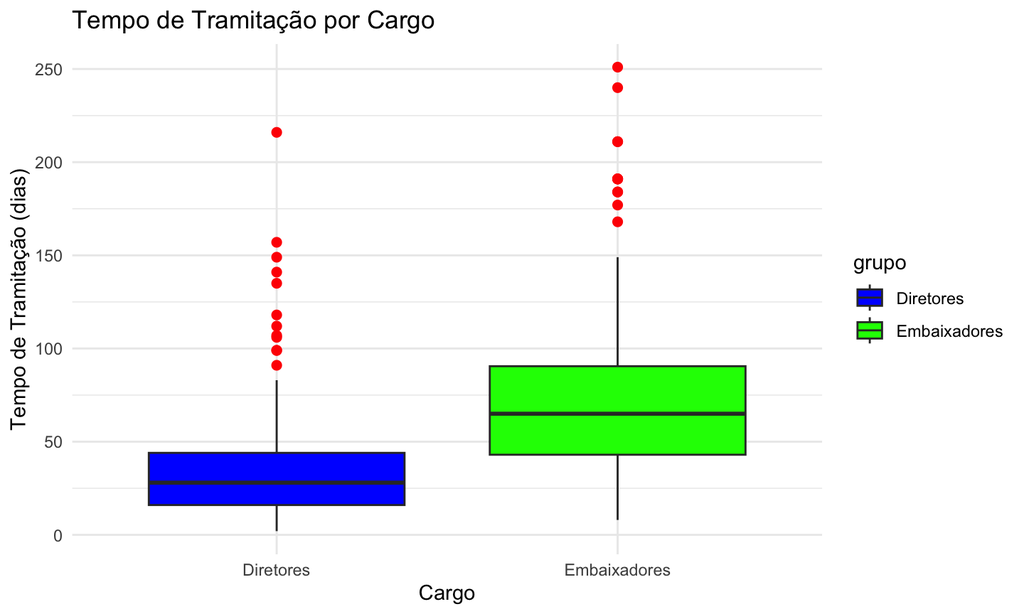

## Conclusões

O teste T comparou a média dos dois grupos propostos: diretores e embaixadores, da variável tempo de tramitação.

O teste T de Welch foi usado pois a variância dos dois grupos não são homogêneas, sendo as aprovações de diretores 151, e de embaixadores 335.

## Valores do teste

t = -9.8157: é o valor estatístico entrado no teste T, que representa a diferença entre as médias dos dois grupos. O sinal negativo indica que a média do grupo “Diretores” é menor do que a do grupo “Embaixadores”, sendo de aproximadamente 37 dias, enquanto do segundo grupo de, aproximadamente, 70 dias.

df = 336.77: é o número de graus de liberdade associado ao teste.

p-value < 2.2e-16: O valor-p (p-value) é extremamente pequeno, indicando que há evidências muito fortes contra a hipótese nula, ou seja, a diferença entre as médias dos dois grupos é estatisticamente significativa.

Intervalo de confiança de 95%:-40.25640 -26.81545: o resultado negativo sugere que um grupo tem a média significativamente menor comparado ao outro, e resulta em 95% de confiança de que, de fato, o intervalo está entre estes números.

## Estimativas das médias dos grupos e conclusão final

A média do tempo de tramitação para o grupo “Diretores” = 37.16556 A média do tempo de tramitação para o grupo “Embaixadores” = 70.70149

Resumindo, o teste revela que há uma diferença estatisticamente significativa entre os tempos de tramitação até a aprovação dos dois grupos. O grupo “Diretores” tem uma média de tempo menor do que o grupo “Embaixadores”, e a diferença é bastante significativa.

O que sugere que o grau de importância do cargo é considerado no processo de aprovação de autoridades, uma vez que os cargos de diretoria são necessários para a governabilidade nacional.